# PatientProfiles - Soluciones

Iniciación práctica al análisis de datos OMOP

Author

Affiliation

Real World Epidemiology

IDIAP Jordi Gol

## Objetivo

El objetivo de esta práctica es caracterizar una población a partir de varias tablas de una base de datos en formato OMOP. Veremos cómo añadir de forma sencilla información demográfica, combinar tablas y hacer una tabla descriptiva.

## ¿Cómo funciona?

En este fichero encontrarás una serie de ejercicios que te proponemos, acompañados de teoría y pistas para su resolución. Puedes crear un script.R en el mismo directorio donde está este fichero, e ir resolviéndolos en el script. En cada ejercicio hay pistas, puesto que el curso es abierto a muchos perfiles y habrá personas que necesitarán indicaciones sobre programación en R y otras sobre dónde encontrar las cosas en OMOP. Además, en este mismo directorio, hay un fichero adicional con las soluciones a los ejercicios, para que puedas autocorregirte la práctica. Si tienes cualquier duda, pregunta a los docentes de apoyo en las prácticas, ¡e intenta utilizar las soluciones solo para corregir!

## Paquetes R que necesitarás

Los nuevos paquetes que utilizarás en esta práctica son los siguientes:

- **PatientProfiles:** para poder caracterizar los individuos dentro de las tablas del CDM con información a nivel de individuo y para tus cohortes.
- **CohortCharacteristics:** para poder caracterizar tus cohortes.

```r
library(dplyr)
library(CohortConstructor)
#install.packages("PatientProfiles")
library(PatientProfiles)
#install.packages("CohortCharacteristics")
library(CohortCharacteristics)
```

## Conexión

Revisamos lo que hemos hecho en las otras prácticas.

- Conéctate a SIDIAP-OMOP, o en este caso, a la base de datos sintética.

El siguiente código establece conexión con la base de datos.

```r
db <- DBI::dbConnect(
  duckdb::duckdb(),
  CDMConnector::eunomiaDir("synthea-covid19-10k")
)
```

- Crea el objeto cdm y crea la cohorte de COVID-19 en caso que se te haya borrado de la práctica anterior. Puedes comprobar si todavía la tienes inspeccionando tu objeto cdm dentro de cohort tables. Para esta práctica solamente trabajaremos con la cohorte de diagnósticos de covid.

```r
cdm <- CDMConnector::cdmFromCon(
  db,
  cdmSchema = "main",
  writeSchema = "main"
)

cdm
```

```
── # OMOP CDM reference (duckdb) of Synthea ────────────────────────────────────
```

```
• omop tables: attribute_definition, care_site, cdm_source, cohort_definition,
concept, concept_ancestor, concept_class, concept_relationship,
concept_synonym, condition_era, condition_occurrence, cost, death,
device_exposure, domain, dose_era, drug_era, drug_exposure, drug_strength,
fact_relationship, location, measurement, metadata, note, note_nlp,
observation, observation_period, payer_plan_period, person,
procedure_occurrence, provider, relationship, source_to_concept_map, specimen,
visit_detail, visit_occurrence, vocabulary
```

```
• cohort tables: -
```

```
• achilles tables: -
```

```
• other tables: -
```

```r
covid_table <- read.csv(here::here("covid.csv"))

covid_list <- list("covid" = covid_table$concept_id)

cdm$covid <- CohortConstructor::conceptCohort(
  cdm=cdm,
  conceptSet = covid_list,
  name = "covid"
)
```

```
ℹ Subsetting table condition_occurrence using 5 concepts with domain:
  condition.
```

```
ℹ Combining tables.
ℹ Creating cohort attributes.
ℹ Applying cohort requirements.
ℹ Merging overlapping records.
✔ Cohort covid created.
```

```r
cdm$covid |> omopgenerics::cohortCount()
```

```
# A tibble: 1 × 3
  cohort_definition_id number_records number_subjects
                 <int>          <int>           <int>
1                    1            964             964
```

## Ejercicios

### Ejercicio 1

##### a) ¿Cuántas mujeres y hombres tenemos en nuestra cohorte?

Utiliza las herramientas de **PatientProfiles** para añadir e identificar la composición por sexo de la cohorte de COVID-19, reportando los totales por categoría.

**Pista**

Sobrescribe la tabla covid para añadir el sexo y haz lo mismo para las variables que vayas añadiendo a lo largo de la práctica. El argumento name usado en muchas de las funciones que veremos sirve para crear una nueva tabla (o sobrescribir una existente con el mismo nombre)

```r
cdm$covid <- cdm$covid |>
  addSex(name="covid")

cdm$covid |>
  group_by(sex) |>
  tally()
```

```
# Source:   SQL [?? x 2]
# Database: DuckDB 1.4.4 [agiuliodori@Windows 10 x64:R 4.4.0/C:\Users\agiuliodori\AppData\Local\Temp\RtmpYLPcXI\file50c2f8ef9f.duckdb]
  sex        n
  <chr>  <dbl>
1 Male     467
2 Female   497
```

##### b) ¿Existen diferencias en la edad media entre hombres y mujeres?

Calcula la edad media (con su desviación estándar) de los pacientes en el momento de su entrada en la cohorte (index date).

**Pista**

Puedes utilizar las funciones summarise(), mean() y sd()

```r
cdm$covid <- cdm$covid |>
  addAge(name="covid")

cdm$covid |>
  group_by(sex) |>
  summarise(
    mean_age = mean(age, na.rm=TRUE),
    sd_age = sd(age, na.rm=TRUE))
```

```
# Source:   SQL [?? x 3]
# Database: DuckDB 1.4.4 [agiuliodori@Windows 10 x64:R 4.4.0/C:\Users\agiuliodori\AppData\Local\Temp\RtmpYLPcXI\file50c2f8ef9f.duckdb]
  sex    mean_age sd_age
  <chr>     <dbl>  <dbl>
1 Male       47.2   29.9
2 Female     44.8   29.0
```

##### c) ¿Cuántos pacientes tienen menos de 1 año de historia clínica documentada antes de su entrada en la cohorte?

El tiempo de observación previa es fundamental para asegurar la calidad de los datos históricos. Añade la observación previa a tu cohorte e identifica cuántos pacientes de la cohorte de COVID-19 tienen menos de 1 año de historia clínica documentada antes de su entrada en la cohorte.

```r
cdm$covid <- cdm$covid |>
  addPriorObservation(name="covid")

cdm$covid |>
  filter(prior_observation < 365) |>
  tally()
```

```
# Source:   SQL [?? x 1]
# Database: DuckDB 1.4.4 [agiuliodori@Windows 10 x64:R 4.4.0/C:\Users\agiuliodori\AppData\Local\Temp\RtmpYLPcXI\file50c2f8ef9f.duckdb]
      n
  <dbl>
1    18
```

### Ejercicio 2

##### a) Crea una cohorte de enfermedades cardiovasculares (complicaciones COVID-19)

En esta práctica, utilizaremos un listado de códigos diagnósticos (que hemos definido previamente utilizando CodeListGenerator), para identificar individuos con enfermedades cardiovasculares y caracterizar a los pacientes con COVID-19. En este caso queremos investigar las siguientes complicaciones: Infarto agudo de miocardio, insuficiencia cardíaca, accidente cerebrovascular y tromboembolismo venoso.

El primer paso será crear las cohortes con el listado de códigos ara identificar estas complicaciones (**cvd_complications.csv** en esta carpeta).

Puedes leer el listado de condiciones de la siguiente manera:

```r
codelist_cvd <- read.csv(here::here("cvd_complications.csv"))
codelist_cvd <- split(as.integer(codelist_cvd$concept_id), codelist_cvd$cohort_name)
```

**Pista**

Tendrás que utilizar el paquete de CohortConstructor que hemos visto esta mañana.

```r
cdm$cvd <- CohortConstructor::conceptCohort(
  cdm=cdm,
  conceptSet = codelist_cvd,
  name = "cvd"
)
```

```
✖ Domain NA (139 concepts) excluded because it is not supported.
ℹ Subsetting table condition_occurrence using 706 concepts with domain:
  condition.
ℹ Combining tables.
ℹ Creating cohort attributes.
ℹ Applying cohort requirements.
ℹ Merging overlapping records.
✔ Cohort cvd created.
```

##### b) Explora qué ID’s las identifican y cuántas personas captamos en cada uno de ellos.

```r
cdm$cvd  |> omopgenerics::settings()
```

```
# A tibble: 4 × 4
  cohort_definition_id cohort_name cdm_version vocabulary_version
                 <int> <chr>       <chr>       <chr>
1                    1 heartf      5.3         v5.0 22-JUN-22
2                    2 mi          5.3         v5.0 22-JUN-22
3                    3 stroke      5.3         v5.0 22-JUN-22
4                    4 vte         5.3         v5.0 22-JUN-22
```

```r
cdm$cvd |> omopgenerics::cohortCount()
```

```
# A tibble: 4 × 3
  cohort_definition_id number_records number_subjects
                 <int>          <int>           <int>
1                    1             17              17
2                    2            510             510
3                    3              0               0
4                    4              0               0
```

**Pista**

¡Recuerda los atributos settings() y cohortCount() de las cohortes!

##### c) ¿Cuántos casos de COVID-19 tuvieron un evento de insuficiencia cardíaca en el mes siguiente a la infección?

**Pista: pasos a seguir**

1. Considerando que nos interesa saber si han tenido o no el evento, identifica cuáles de las funciones intersect debemos utilizar.
2. Identifica el ID de la cohorte insuficiencia cardíaca en la tabla de las enfermedades cardiovasculares.
3. Define la ventana temporal.
4. Utiliza el argumento “nameStyle” para darle el nombre que quieras a la columna que se va a crear con la intersección.
5. Cuenta el número de eventos de interés.

```r
cdm$covid |>
  addCohortIntersectFlag(
    targetCohortTable = "cvd",
    targetCohortId = 1,
    window = list(c(0,30)),
    nameStyle = "mi_30d"
  )|>
  filter(mi_30d == 1) |>
  distinct(subject_id) |>
  tally()
```

```
# Source:   SQL [?? x 1]
# Database: DuckDB 1.4.4 [agiuliodori@Windows 10 x64:R 4.4.0/C:\Users\agiuliodori\AppData\Local\Temp\RtmpYLPcXI\file50c2f8ef9f.duckdb]
      n
  <dbl>
1    17
```

##### d) ¿En estos pacientes, cuántos días de media pasaron desde la infección por COVID-19 y el primer evento de insuficiencia cardíaca?

```r
cdm$covid |>
  addCohortIntersectDays(
    targetCohortTable = "cvd",
    targetCohortId = 1,
    indexDate = "cohort_start_date",
    order ="first",
    window = c(0, Inf)
  ) |>
  filter(!is.na(heartf_0_to_inf)) |>
  summarise(mean_days = mean(heartf_0_to_inf, na.rm = TRUE))
```

```
# Source:   SQL [?? x 1]
# Database: DuckDB 1.4.4 [agiuliodori@Windows 10 x64:R 4.4.0/C:\Users\agiuliodori\AppData\Local\Temp\RtmpYLPcXI\file50c2f8ef9f.duckdb]
  mean_days
      <dbl>
1      8.41
```

**Pista**

Piensa cuál es la función intersect más adecuada en este caso, y el intervalo de tiempo que nos interesa. Recuerda que ahora estamos hablando de otra cohorte dentro de cvds.

```r
cdm$covid |>
  addCohortIntersectCount(
    targetCohortTable = "cvd",
    targetCohortId = 1,
    window = list(c(0,365)),
    nameStyle = "mi"
  ) |>
  filter(mi > 1) |>
  tally()
```

```
# Source:   SQL [?? x 1]
# Database: DuckDB 1.4.4 [agiuliodori@Windows 10 x64:R 4.4.0/C:\Users\agiuliodori\AppData\Local\Temp\RtmpYLPcXI\file50c2f8ef9f.duckdb]
      n
  <dbl>
1     0
```

### Ejercicio 3

##### a) Queremos caracterizar a los pacientes COVID-19 después de la infección.

Vamos a calcular los campos de una tabla 1 que contenga:

- Min, Mediana, cuantiles del 25 y 75% y max de la edad

- Número y proporción (%) de los grupos de edad (0-18, 19-69, 70+)

- Número y proporción (%) de cada sexo

- Min, Mediana, cuantiles del 25 y 75% y max de tiempo de observación previa

- Número y proporción (%) de gente que ha experimentado en cualquier momento después del diagnóstico por COVID-19 cada una de las enfermedades cardiovasculares que estamos tratando

Utiliza las funciones del paquete **CohortCharacteristics** para facilitarte el trabajo.

**Pista**

Es importante tener en cuenta que deberás añadir los grupos de edad especificados. El argumento ageGroup te ayudará con esto.

```r
result_age <-  cdm$covid |>
  summariseCharacteristics(
    ageGroup = list(c(0,18), c(19,69), c(70,150)),
    cohortIntersectFlag = list(
      "Cvds any time after" = list(
        targetCohortTable = "cvd", window = c(0, Inf)

  )))
```

```
ℹ adding demographics columns
```

```
ℹ adding cohortIntersectFlag 1/1
window names casted to snake_case:
ℹ summarising data

ℹ summarising cohort covid

✔ summariseCharacteristics finished!
```

```r
result_age |> tableCharacteristics()
```

| Variable name | Variable level | Estimate name | CDM name Synthea Cohort name covid |
| --- | --- | --- | --- |
| Number records | – | N | 964 |
| Number subjects | – | N | 964 |
| Cohort start date | – | Median [Q25 - Q75] | 2020-12-13 [2020-10-22 - 2021-01-31] |
|  |  | Range | 2020-03-15 to 2021-09-14 |
| Cohort end date | – | Median [Q25 - Q75] | 2021-01-05 [2020-11-11 - 2021-02-25] |
|  |  | Range | 2020-03-15 to 2021-10-12 |
| Age | – | Median [Q25 - Q75] | 45 [20 - 72] |
|  |  | Mean (SD) | 45.97 (29.46) |
|  |  | Range | 0 to 97 |
| Age group | 0 to 18 | N (%) | 229 (23.76%) |
|  | 19 to 69 | N (%) | 480 (49.79%) |
|  | 70 to 150 | N (%) | 255 (26.45%) |
| Sex | Female | N (%) | 497 (51.56%) |
|  | Male | N (%) | 467 (48.44%) |
| Prior observation | – | Median [Q25 - Q75] | 2,518 [2,278 - 2,708] |
|  |  | Mean (SD) | 3,150.33 (3,034.46) |
|  |  | Range | 56 to 31,628 |
| Future observation | – | Median [Q25 - Q75] | 665 [488 - 803] |
|  |  | Mean (SD) | 612.76 (266.73) |
|  |  | Range | 0 to 1,159 |
| Days in cohort | – | Median [Q25 - Q75] | 24 [17 - 31] |
|  |  | Mean (SD) | 23.48 (9.38) |
|  |  | Range | 1 to 38 |
| Days to next record | – | Median [Q25 - Q75] | – |
|  |  | Mean (SD) | – |
|  |  | Range | – |
| Cvds any time after | Heartf | N (%) | 17 (1.76%) |
|  | Mi | N (%) | 3 (0.31%) |
|  | Stroke | N (%) | 0 (0.00%) |
|  | Vte | N (%) | 0 (0.00%) |

##### b) Repite el ejercicio 3a, pero ahora con el objetivo de generar una tabla que caracterice a hombres y mujeres por separado.

**Pista**

Para usar el argumento strata, la variable debe haber sido añadida previamente como una columna adicional en la tabla de la cohorte.

```r
result_sex <- cdm$covid |>
  addSex() |>
  summariseCharacteristics(
    strata = list("sex"),
    ageGroup = list(c(0,18), c(19,69), c(70,150)),
    cohortIntersectFlag = list(
      "Cvds any time after" = list(
        targetCohortTable = "cvd", window = c(0, Inf)

  )))
```

```
ℹ adding demographics columns
```

```
ℹ adding cohortIntersectFlag 1/1
window names casted to snake_case:
ℹ summarising data

ℹ summarising cohort covid

✔ summariseCharacteristics finished!
```

```r
result_sex |> tableCharacteristics(header = "sex")
```

| CDM name | Cohort name | Variable name | Variable level | Estimate name | Sex overall | Sex Female | Sex Male |
| --- | --- | --- | --- | --- | --- | --- | --- |
| Synthea | covid | Number records | – | N | 964 | 497 | 467 |
|  |  | Number subjects | – | N | 964 | 497 | 467 |
|  |  | Cohort start date | – | Median [Q25 - Q75] | 2020-12-13 [2020-10-22 - 2021-01-31] | 2020-12-17 [2020-10-19 - 2021-02-01] | 2020-12-09 [2020-10-27 - 2021-01-31] |
|  |  |  |  | Range | 2020-03-15 to 2021-09-14 | 2020-03-16 to 2021-09-14 | 2020-03-15 to 2021-09-08 |
|  |  | Cohort end date | – | Median [Q25 - Q75] | 2021-01-05 [2020-11-11 - 2021-02-25] | 2021-01-07 [2020-11-08 - 2021-02-25] | 2021-01-02 [2020-11-15 - 2021-02-24] |
|  |  |  |  | Range | 2020-03-15 to 2021-10-12 | 2020-04-01 to 2021-10-12 | 2020-03-15 to 2021-09-27 |
|  |  | Age | – | Median [Q25 - Q75] | 45 [20 - 72] | 44 [20 - 69] | 46 [20 - 76] |
|  |  |  |  | Mean (SD) | 45.97 (29.46) | 44.85 (29.00) | 47.16 (29.91) |
|  |  |  |  | Range | 0 to 97 | 0 to 97 | 0 to 97 |
|  |  | Age group | 0 to 18 | N (%) | 229 (23.76%) | 120 (24.14%) | 109 (23.34%) |
|  |  |  | 19 to 69 | N (%) | 480 (49.79%) | 254 (51.11%) | 226 (48.39%) |
|  |  |  | 70 to 150 | N (%) | 255 (26.45%) | 123 (24.75%) | 132 (28.27%) |
|  |  | Sex | Female | N (%) | 497 (51.56%) | 497 (100.00%) | – |
|  |  |  | Male | N (%) | 467 (48.44%) | – | 467 (100.00%) |
|  |  | Prior observation | – | Median [Q25 - Q75] | 2,518 [2,278 - 2,708] | 2,513 [2,234 - 2,675] | 2,538 [2,326 - 2,738] |
|  |  |  |  | Mean (SD) | 3,150.33 (3,034.46) | 2,918.90 (2,514.67) | 3,396.63 (3,489.97) |
|  |  |  |  | Range | 56 to 31,628 | 56 to 21,423 | 72 to 31,628 |
|  |  | Future observation | – | Median [Q25 - Q75] | 665 [488 - 803] | 677 [483 - 812] | 657 [488 - 796] |
|  |  |  |  | Mean (SD) | 612.76 (266.73) | 619.56 (262.43) | 605.52 (271.31) |
|  |  |  |  | Range | 0 to 1,159 | 0 to 1,159 | 0 to 1,103 |
|  |  | Days in cohort | – | Median [Q25 - Q75] | 24 [17 - 31] | 24 [17 - 31] | 24 [17 - 31] |
|  |  |  |  | Mean (SD) | 23.48 (9.38) | 23.70 (9.07) | 23.24 (9.71) |
|  |  |  |  | Range | 1 to 38 | 1 to 38 | 1 to 38 |
|  |  | Days to next record | – | Median [Q25 - Q75] | – | – | – |
|  |  |  |  | Mean (SD) | – | – | – |
|  |  |  |  | Range | – | – | – |
|  |  | Cvds any time after | Heartf | N (%) | 17 (1.76%) | 6 (1.21%) | 11 (2.36%) |
|  |  |  | Mi | N (%) | 3 (0.31%) | 1 (0.20%) | 2 (0.43%) |
|  |  |  | Stroke | N (%) | 0 (0.00%) | 0 (0.00%) | 0 (0.00%) |
|  |  |  | Vte | N (%) | 0 (0.00%) | 0 (0.00%) | 0 (0.00%) |

##### c) Distribución de eventos CVD tras fecha índice

Represente gráficamente el porcentaje de sujetos en la cohorte COVID-19 con presencia de enfermedad cardiovascular (CVD) en cualquier momento posterior a la fecha índice, estratificando los resultados por sexo (hombres y mujeres).

**Pista**

Selecciona las filas deseadas en las columnas variable_name y estimate_name del objeto obtenido con summariseCharacteristics().

Utiliza la función plotCharacteristics(), ajustando los argumentos necesarios para cumplir con los requisitos de diseño indicados.

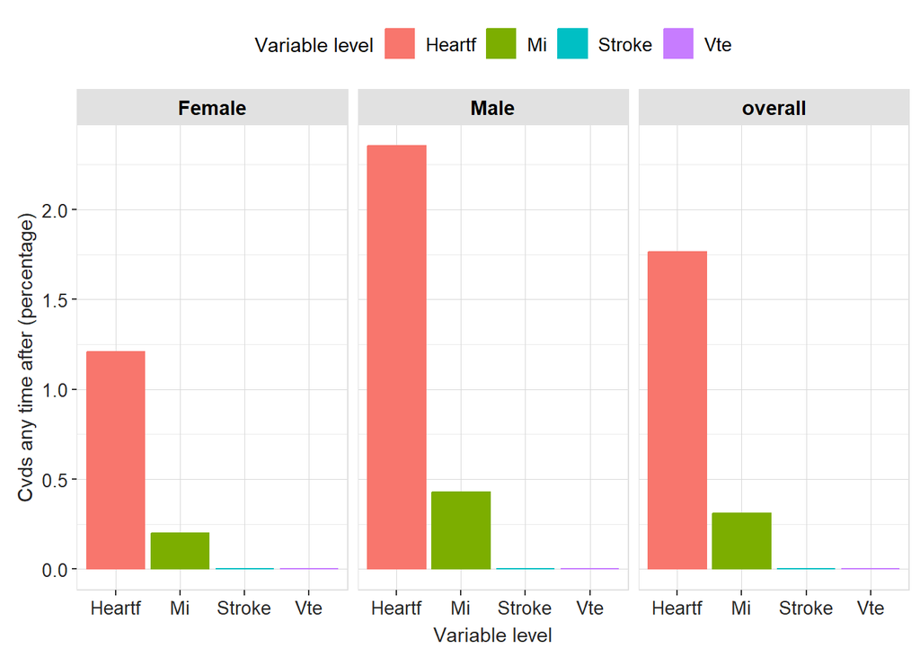

```r
plot_data <- result_sex |>
  filter(
    variable_name == "Cvds any time after",
    estimate_name == "percentage"
  )

plot_data |>
  plotCharacteristics(
    plotType = "barplot",
    colour = "variable_level",
    facet = c("sex")
  )
```

### Ejercicio 4

##### Caracterización de fármacos y comorbilidades en ventanas pre y post índice

Genera una tabla descriptiva del uso de fármacos y la presencia de comorbilidades para la cohorte de COVID-19. El análisis debe diferenciar entre el periodo pre-índice (año previo) y el post-índice (año posterior), reportando los 10 conceptos más prevalentes en cada categoría.

**Pista**

Utiliza primero summariseLargeScaleCharacteristics() y, posteriormente, formatea el resultado con una de las funciones table().

Ventanas temporales: Asegúrate de especificar correctamente los intervalos de tiempo para el año previo y el posterior.

Selección de tablas: Debes indicar en qué tablas del cdm quieres buscar los eventos (para comorbilidades) y episodios (para fármacos).

Nota técnica: Recuerda que las ventanas temporales se definen como una lista de vectores numéricos. Por ejemplo, para capturar el año previo y el año posterior, el argumento sería: window = list(c(-365, -1), c(1, 365)).

```r
result_comorbi <- cdm$covid |>
  summariseLargeScaleCharacteristics(
    window = list(c(-365, -1), c(1, 365)),
    eventInWindow = "condition_occurrence",
    episodeInWindow = "drug_exposure")
```

```
ℹ Summarising large scale characteristics
```

```
 - getting characteristics from table condition_occurrence (1 of 2)
```

```
 - getting characteristics from table condition_occurrence (1 of 2) for time wi…
 - getting characteristics from table condition_occurrence (1 of 2) for time wi…
```

```
 - getting characteristics from table drug_exposure (2 of 2)
```

```
 - getting characteristics from table drug_exposure (2 of 2) for time window -3…
```

```
 - getting characteristics from table drug_exposure (2 of 2) for time window 1 …
```

```
Formatting result
```

```
28 estimates dropped as frequency less than 0.5%
✔ Summarising large scale characteristics
```

```r
tableTopLargeScaleCharacteristics(result_comorbi, topConcepts = 10)
```

| Top | Window -365 to -1 Table name condition_occurrence Type event | Window -365 to -1 Table name drug_exposure Type episode | Window 1 to 365 Table name condition_occurrence Type event | Window 1 to 365 Table name drug_exposure Type episode |
| --- | --- | --- | --- | --- |
| 1 | Fever (437663) 51 (5.3%) | Influenza, seasonal, injectable, preservative free (40213154) 759 (78.7%) | Acute deep venous thrombosis (44782746) 60 (6.3%) | Influenza, seasonal, injectable, preservative free (40213154) 738 (77.5%) |
| 2 | Cough (254761) 43 (4.5%) | tetanus and diphtheria toxoids, adsorbed, preservative free, for adult use (5 Lf of tetanus toxoid and 2 Lf of diphtheria toxoid) (40213227) 66 (6.8%) | Acute pulmonary embolism (45768439) 58 (6.1%) | acetaminophen 500 MG Oral Tablet (19020053) 164 (17.2%) |
| 3 | Loss of taste (4289517) 26 (2.7%) | diphtheria, tetanus toxoids and acellular pertussis vaccine (40213281) 52 (5.4%) | Acute respiratory distress syndrome (4195694) 29 (3.0%) | 0.4 ML enoxaparin sodium 100 MG/ML Prefilled Syringe (40160973) 152 (16.0%) |
| 4 | Fatigue (4223659) 19 (2.0%) | poliovirus vaccine, inactivated (40213160) 45 (4.7%) | Heart failure (316139) 17 (1.8%) | 1 ML enoxaparin sodium 150 MG/ML Prefilled Syringe (40160997) 122 (12.8%) |
| 5 | Sputum finding (4089228) 17 (1.8%) | pneumococcal conjugate vaccine, 13 valent (40213198) 37 (3.8%) | Injury of kidney (4220631) 16 (1.7%) | tetanus and diphtheria toxoids, adsorbed, preservative free, for adult use (5 Lf of tetanus toxoid and 2 Lf of diphtheria toxoid) (40213227) 69 (7.2%) |
| 6 | Dyspnea (312437) 14 (1.4%) | measles, mumps and rubella virus vaccine (40213183) 32 (3.3%) | Acquired coagulation disorder (4120613) 15 (1.6%) | NDA020503 200 ACTUAT albuterol 0.09 MG/ACTUAT Metered Dose Inhaler (1511248) 64 (6.7%) |
| 7 | Wheezing (314754) 14 (1.4%) | varicella virus vaccine (40213251) 32 (3.3%) | Septic shock (196236) 15 (1.6%) | meningococcal polysaccharide (groups A, C, Y and W-135) diphtheria toxoid conjugate vaccine (MCV4P) (40213180) 35 (3.7%) |
| 8 | Atrial fibrillation (313217) 13 (1.4%) | human papilloma virus vaccine, quadrivalent (40213320) 31 (3.2%) | Injury of heart (4311280) 13 (1.4%) | diphtheria, tetanus toxoids and acellular pertussis vaccine (40213281) 32 (3.4%) |
| 9 | Joint pain (77074) 10 (1.0%) | Haemophilus influenzae type b vaccine, PRP-OMP conjugate (40213314) 30 (3.1%) | Bacterial infectious disease (432545) 5 (0.5%) | hepatitis A vaccine, pediatric/adolescent dosage, 2 dose schedule (40213299) 32 (3.4%) |
| 10 | Muscle pain (442752) 10 (1.0%) | meningococcal polysaccharide (groups A, C, Y and W-135) diphtheria toxoid conjugate vaccine (MCV4P) (40213180) 30 (3.1%) | Hypoxemia (437390) 5 (0.5%) | pneumococcal conjugate vaccine, 13 valent (40213198) 31 (3.3%) |

### Ejercicio extra

**Pista**

Utiliza el argumento minimumFrequency.

```r
result_comorbi_sex <- cdm$covid |>
  addSex() |>
  summariseLargeScaleCharacteristics(
    window = list(c(1,365)),
    eventInWindow = "condition_occurrence",
    strata = list("sex"),
    minimumFrequency = 0.1)
```

```
ℹ Summarising large scale characteristics
```

```
 - getting characteristics from table condition_occurrence (1 of 1)
```

```
 - getting characteristics from table condition_occurrence (1 of 1) for time wi…
```

```
Formatting result
```

[output not shown]

```r
plot <- result_comorbi_sex |>
  plotLargeScaleCharacteristics(colour = "variable_name", facet = "sex")
```

```
! The following column type were changed:
• variable_level: from integer to character
```

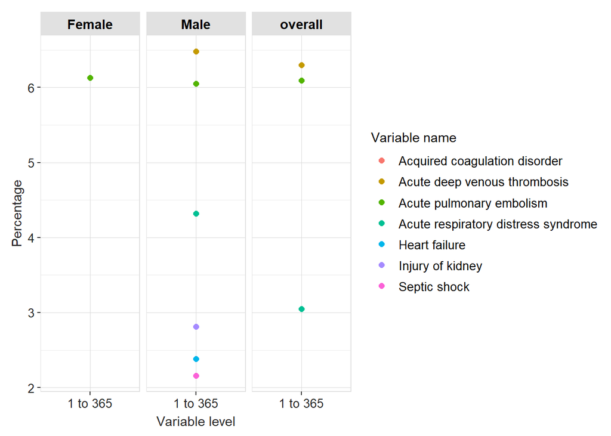

```r
plot
```